# Practical phylogenetic methods for linguistic typology

## 3.4 How to add branch lengths

Branch lengths in a tree convey information, and most phylogenetic comparative methods, including genealogically-sensitive averages and proportions, are sensitive to the information represented by the branch lengths. (To be specific, genealogically-sensitive averages and proportions are sensitive to the *relative* lengths of the branches, so multiplying all of the branch lengths in a tree by some constant amount would not affect the results.)

Glottolog’s trees contain informative subgrouping structure, but the branch lengths are all equal. Even without knowing what the true branch lengths are for a linguistic tree, we do know that a situation in which all are equal is highly unlikely. A good approximation to the most-likely[^8] distribution of branch lengths in a phylogenetic tree, under a variety of assumptions, is exponential (Venditti, Meade, and Pagel 2010), i.e., very long branches are rare, and very short ones are frequent. This notion is implemented in the `glottoTrees` package by the function `rescale_branches_exp()`, which sets the deepest branches to length 1/2, then next layer to length 1/4, then the next to 1/8 and so on. This will produce a more plausible set of branch lengths, even in the absence of firm knowledge of exact lengths, and on these grounds we advocate its use if additional information about branch lengths is not available.

Here is an example of the result of applying exponential branch lengths to glottolog’s Great Andamanese tree:

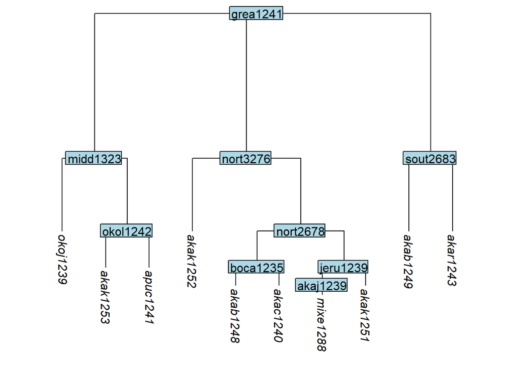

```r
tree_GAp <- rescale_branches_exp(tree_GA_abr)
plot_glotto(tree_GAp)
```

Here is an example of the result of applying them to glottolog’s Eskimo-Aleut tree, of 30 tips:

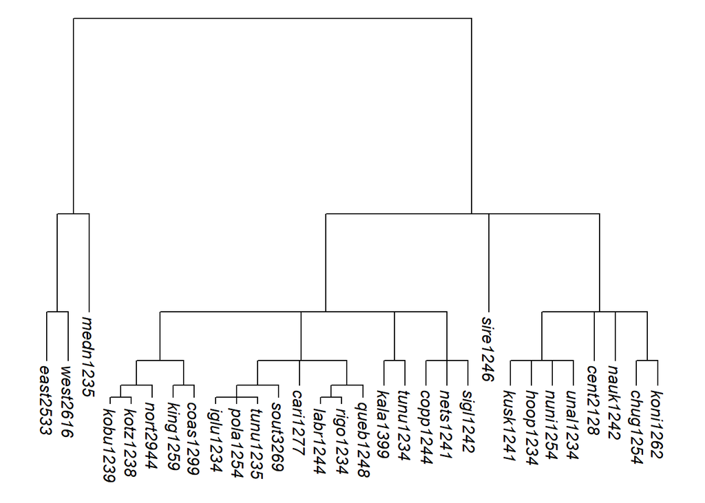

```r
tree_EA <- get_glottolog_trees("Eskimo-Aleut")
tree_EA_abr <- abridge_labels(tree_EA)
tree_EAa <- rescale_branches_exp(tree_EA_abr)
plot_glotto(tree_EAa, nodelabels = FALSE)
```

An additional option is to stretch the terminal branches so that all tips are equidistant from the root, creating what is known as an *ultrametric* tree. This is done using the function `ultrametricize()`.

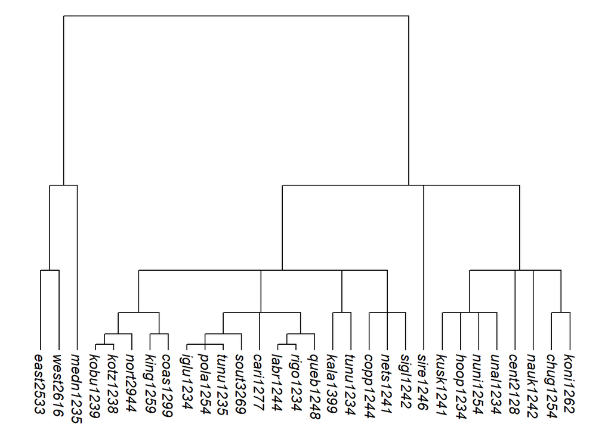

```r
tree_EAb <- ultrametricize(tree_EAa)
plot_glotto(tree_EAb, nodelabels = FALSE)
```

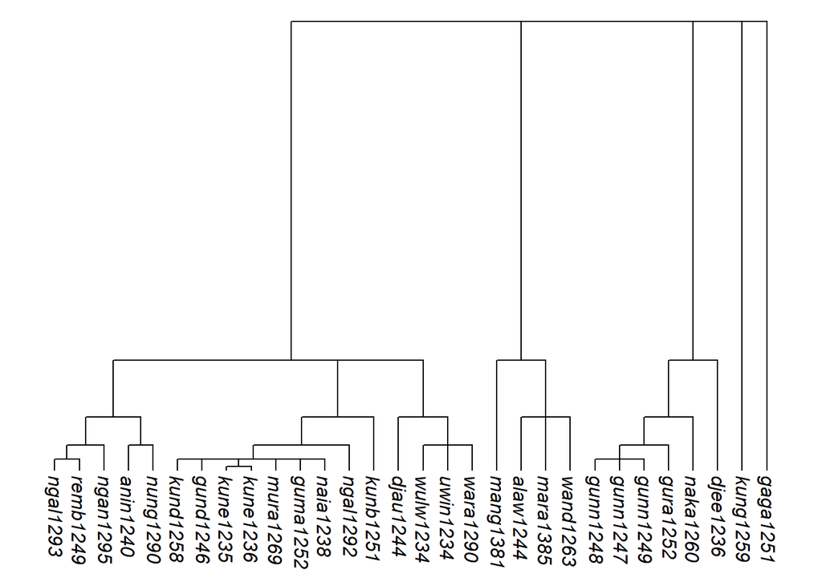

```r
tree_arnhem_a <- rescale_branches_exp(tree_arnhem_abr)
tree_arnhem_b <- rescale_deepest_branches(tree_arnhem_a, 1.5)
tree_arnhem_c <- ultrametricize(tree_arnhem_b)
plot_glotto(tree_arnhem_c, nodelabels = FALSE)
```

## 3.5 Exporting trees for use with other software

In R, trees can be saved to file in Newick format using the function `write.tree()` in the `ape` package. Files like this can be opened by other software such as FigTree[^9], which can be used to interactively generate tree plots that may be useful for publication and dissemination. For instance, here we write the tree `tree_arnhem_c` to a file whose filename ends in the standard file extension, `.tree`:

```r
write.tree(tree_arnhem_c, "my_arnhem_tree.tree")
```

Often it will be desirable to reproduce a tree with labels that are more reader-friendly than glottocodes. `glottoTrees` provides the function `relabel_with_names()`, which will replace full glottolog labels, or labels consisting of just a glottocode, with glottolog’s corresponding language, dialect, subgroup or family name. Here we relabel the Arnhem tree by the languages’ names. As was the case with `abridge_labels()`, warnings are given by `relabel_with_names()` if a tree contains any nodes that cannot be relabeled in this way; these are not errors, just alerts.

```r
tree_arnhem_c_namelabels <- relabel_with_names(tree_arnhem_c)
```

```
## Warning in relabel_with_names(tree_arnhem_c): Labels without glottocodes were detected and left
## unchanged for: 0 tip(s); 1 node(s):
```

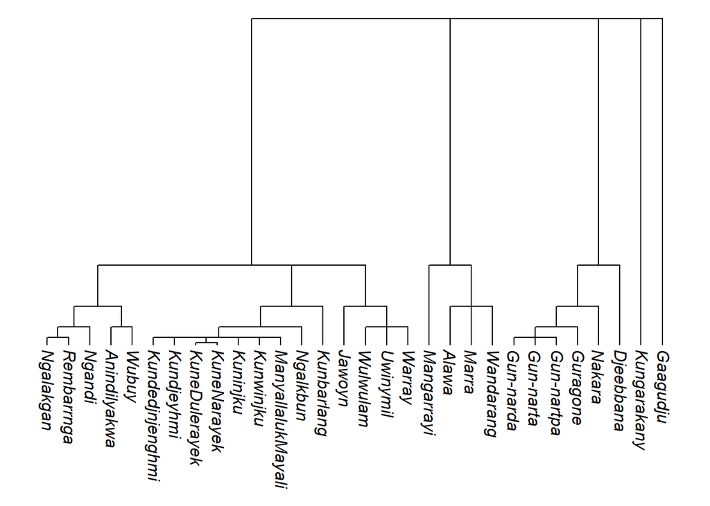

```r
plot_glotto(tree_arnhem_c_namelabels, nodelabels = FALSE)
```

# 4 Putting it together: A worked example

In this section we provide a real worked example of the use of the methods described above.

Yin (2020) examined violations of the sonority sequencing principle in 496 languages, and calculated the genealogically-sensitive proportions of languages in which various violations occurred. The language sample consisted of 496 languages in the CLICS2 database (Anderson et al. 2018) and the AusPhon-Lexicon database (Round 2017). The language sample was not balanced in the traditional sense, and phylogenetic methods were used to help produce a principled interpretation of the data.

```r
head(yin_2020_data, n = 10)
```

[output not shown]

## 4.1 Preparing a tree

The tree for Yin’s study was constructed from a glottolog supertree, using glottolog version 4.2. Yin’s supertree made use of glottolog’s macroareas. Since the language sample covered relatively few families in the Americas, a single group was used for South America and North America. Additionally, the only African language available in the sample was Arabic, so Africa and Eurasia were grouped together:

```r
yin_macro <- list(c("South America", "North America"), c("Africa", "Eurasia"),
                  "Papunesia", "Australia")
supertree <- assemble_supertree(macro_groups = yin_macro, glottolog_version = "4.2")
supertree_abr <- abridge_labels(supertree)
```

Five tips were cloned, in cases where Yin had data for two varieties corresponding to just one tip in the glottolog supertree:

```r
supertree_a <- clone_tip(supertree_abr, subgroup = TRUE,
                         label = c("ayab1239", "basu1242", "biri1256",
                                   "ikar1243", "peri1265"))
supertree_b <- apply_duplicate_suffixes(supertree_a)
```

Eight tips were added, in cases where for sister lects (A,B), glottolog placed A as a node above B. In such cases, in new tip A was placed below the existing glottolog node A:

```r
supertree_c <- supertree_b
nodes_to_add_as_tips <- c("alor1249", "gami1243", "guri1247", "mand1415",
                          "sins1241", "wang1291", "warl1254", "yand1253")
# Loop through these nodes, and use add_tip() to add the new tip:
for (node_i in nodes_to_add_as_tips) {
  supertree_c <- add_tip(supertree_c, label = node_i, parent_label = node_i)
}
```

From this supertree, the 496 languages in Yin’s dataset were kept. The internal node `mada1298` was collapsed, as were all non-branching internal nodes:

```r
supertree_d <- keep_as_tip(supertree_c, label = yin_2020_data$tip)
supertree_e <- collapse_node(supertree_d, label = "mada1298")
supertree_f <- collapse_node(supertree_e, label = nonbranching_nodes(supertree_e))
```

Finally, branch lengths were assigned. Branches were first assigned exponential lengths. Then, in order to diminish the importance of the macro groups, the branches above them were shortened to a length of 1/40. The effect of this decision is that the implied distance between families in different macro groups is only marginally greater than between families within a single macro group.

```r
supertree_g <- rescale_branches_exp(supertree_f)
yin_2020_tree <- rescale_deepest_branches(supertree_g, 1/40)
```

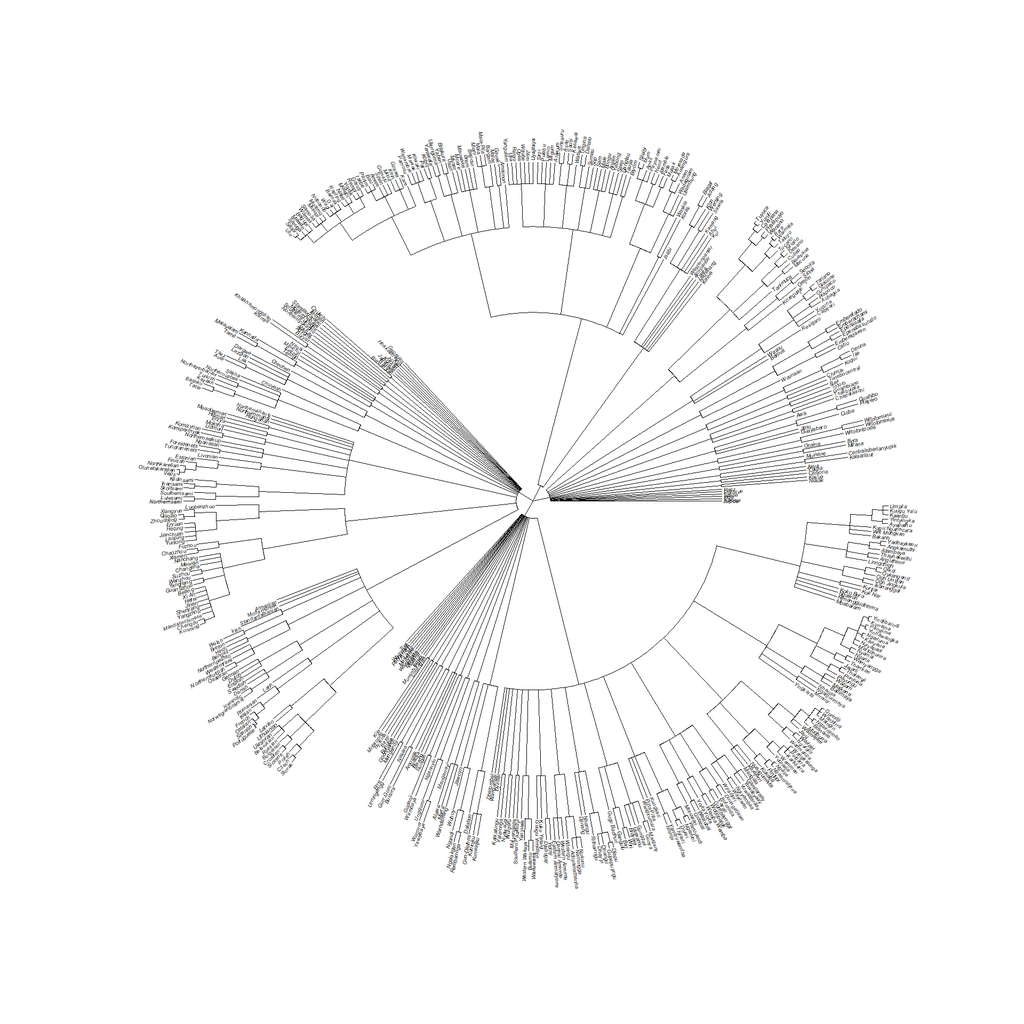

Supertree of 496 languages used in Yin (2020).

```r
full_names <- yin_2020_data$name[match(yin_2020_tree$tip.label, yin_2020_data$tip)]
name_tree <- yin_2020_tree
name_tree$tip.label <- full_names
plot(ladderize(name_tree, right = FALSE), type = "fan",
     cex = 0.3, label.offset = 0.002, edge.width = 0.5)
```

## 4.2 Preparing the dataframe of typological data

In order to calculate phylogenetic weights and genealogically-sensitive proportions, in addition to the tree (or a set of trees) we require a dataframe with (a) one column `tip`, whose contents match the tip labels in the trees, and (b) other columns containing numerical data to be averaged. The dataframe `yin_2020_data` has a column `tip` and two columns of numerical data `has_onset_violation` and `has_coda_violation`, and thus it meets the requirements we need. It also contains a column, `names`, of non-numeric data. Columns of non-numeric data (other than `tip`) are ignored by `phylo_average()`, so we do not need to remove them.

## 4.3 Calculating genealogically-sensitive proportions

The results are calculated using `phylo_average()`, setting its `phy` argument to the tree we have constructed, `yin_2020_tree`, and its `data` argument to the dataframe we have prepared, `yin_2020_data`. A warning is issued alerting us that the dataframe contains a non-numeric column that gets ignored:

```r
yin_2020_results <- phylo_average(phy = yin_2020_tree, data = yin_2020_data)
```

```
## Warning in phylo_average(phy = yin_2020_tree, data = yin_2020_data): `data` contains non-numeric
## columns other than `tip`, which have been ignored: name.
```

```r
yin_2020_results$ACL_averages
yin_2020_results$BM_averages
```

[output not shown]

```r
head(yin_2020_results$ACL_weights, n = 10)
head(yin_2020_results$BM_weights, n = 10)
```

[output not shown]

As a point of comparison, the raw proportions, which are equal to the means of the columns `has_onset_violation` and `has_coda_violation`, are these:

```r
mean(yin_2020_data$has_onset_violation)
```

```
## [1] 0.3649
```

```r
mean(yin_2020_data$has_coda_violation)
```

```
## [1] 0.3145
```

# 5 Using these methods in typological research

As we seek to analyse the empirical diversity of attested languages, there are fundamental reasons why genealogy must be part of picture (see Macklin-Cordes and Round 2021a). And since the genealogies of human languages are still incompletely known, it is imperative to make our phylogenetic hypotheses and assumptions as explicit and as testable as possible. In this document, we hope have shown that doing so is entirely feasible.

Through the use of `glottoTrees` and `phyloWeights`, we hope that in the future, linguistic trees and the code used to produce them can be published together with typological studies. This will enable subsequent researchers to replicate the study’s findings, and just as importantly, to modify its assumptions by modifying the trees, and thereby to test further hypotheses inspired by the initial research.

If you find these practical tools useful in your own research, please cite the packages as E. R. Round (2021a) and E. R. Round (2021b). If you wish to cite the notion of genealogically-sensitive averages and proportions, please cite either Macklin-Cordes and Round (2021a) and/or the more specific references therein.

If you think you’ve encountered a bug or anomalous behaviour in `glottoTrees` and `phyloWeights`, please be in contact, either through the package github pages or by email: e.round@uq.edu.au. It’s important for the good of the science that linguists can use these methods without undue impediments.

# Citation & Session Info

Round, Erich. 2021. *Practical phylogenetic comparative methods for linguistic typology*. Surrey Morphology Group, University of Surrey & Ancient Language Lab, University of Queensland. url: https://slcladal.github.io/phylo_for_typology.html (Version 2021.11.04).

```
@manual{Round2021net,
  author = {Round, Erich},
  title = {Practical phylogenetic comparative methods for linguistic typology},
  note = {https://slcladal.github.io/phylo_for_typology.html},
  year = {2021},
  organization = {{Surrey Morphology Group, University of Surrey} and {Ancient Language Lab, School of Languages and Cultures, University of Queensland}},
  address = {{Guildford, UK} and {St Lucia, QLD}},
  edition = {2021.11.04}
}
```

Back to top

[Back to HOME](https://slcladal.github.io/index.html)

# References

Altschul, Stephen F., Raymond J. Carroll, and David J. Lipman. 1989. “Weights for Data Related by a Tree.” *Journal of Molecular Biology* 207 (4): 647–53.

Anderson, Cormac, Robert Forkel, Simon J Greenhill, Johann-Mattis List, Christoph Rzymski, and Tiago Tresoldi. 2018. “CLICS2: An Improved Database of Cross-Linguistic Colexifications Assembling Lexical Data with the Help of Cross-Linguistic Data Formats.” *Linguistic Typology* 22 (2): 277–306.

Felsenstein, Joseph. n.d. *The Newick Tree Format*. http://evolution.genetics.washington.edu/phylip/newicktree.html.

Green, Rebecca. 2003. “Proto Maningrida with Proto Arnhem: Evidence from Verbal Inflectional Suffixes.” In *The Non-Pama-Nyungan Languages of Northern Australia : Comparative Studies of the Continent’s Most Linguistically Complex Region*, edited by Nicholas Evans, 369–421. Pacific Linguistics.

Hammarström, Harald, Robert Forkel, Martin Haspelmath, and Sebastian Bank. 2021. *Glottolog 4.4*. Leipzig: Max Planck Institute for Evolutionary Anthropology. https://doi.org/10.5281/zenodo.4761960.

Macklin-Cordes, Jayden, and Erich R Round. 2021a. “Challenges of Sampling and How Phylogenetic Comparative Methods Help: With a Case Study of the Pama-Nyungan Laminal Contrast.”

———. 2021b. “Phylogenetic Comparative Methods: What All the Fuss Is About, and How to Use Them in Everyday Research.” Brisbane.

Round, Erich R. 2017. “The AusPhon-Lexicon Project: 2 Million Normalized Segments Across 300 Australian Languages.”

———. 2021a. *glottoTrees: Phylogenetic Trees in Linguistics.* https://github.com/erichround/glottoTrees.

———. 2021b. *phyloWeights: Calculation of Genealogically-Sensitive Proportions and Averages*. https://github.com/erichround/phyloWeights.

Stone, Eric A., and Arend Sidow. 2007. “Constructing a Meaningful Evolutionary Average at the Phylogenetic Center of Mass.” *BMC Bioinformatics* 8 (1): 222.

Venditti, Chris, Andrew Meade, and Mark Pagel. 2010. “Phylogenies Reveal New Interpretation of Speciation and the Red Queen.” *Nature* 463 (7279): 349–52.

Yin, Ruihua. 2020. “Violations of the Sonority Sequencing Principle: How, and How Often?” https://als.asn.au/Conference/Program.

[^1]: See online documentation of the `ape` package for reading trees from various common file formats.
[^2]: Although this file is named `tree_glottolog_newick.txt`, it is not in true Newick format due to its use of square brackets in node and tip labels (Felsenstein, n.d.). In `glottoTrees`, the square brackets in glottolog’s file are converted to angled brackets (i.e., greater-than and less-than symbols), to bring them into conformity with the Newick standard.
[^3]: There are two exceptional glottocodes with numbers in the initial four characters: b10b1234 and 3adt1234.
[^4]: The differences are systematic and are made in order to conform with the permissible Newick format of tree labels: spaces and apostrophes are removed, parentheses are replaced by braces, and commas are replaced by forward slashes.
[^5]: `glottoTrees` currently contains information from glottolog versions 4.0, 4.1, 4.2, 4.3 and 4.4 (which is current at time of writing). Our intention is to update `glottoTrees` as glottolog updates in the future.
[^6]: Converting nodes into tips may cause them to move to the left or right in the tree plot. The movement is meaningless, since a subgroup (A, B) is exactly the same as subgroup (B, A). Since the movement is meaningless, it’s also harmless.
[^7]: `apply_duplicate_suffixes()` will also add suffixes to any nodes with duplicate labels.
[^8]: ‘Most likely’ doesn’t mean that we expect to see trees with exactly these branch lengths. Compare this to flipping a coin two million times: although it is unlikely that the outcome will be exactly one million heads and one million tails, it remains true that one million heads and one million tails is the most likely outcome, in the strict sense that it is more likely than any other outcome. The branch lengths discussed here are ‘most likely’ is a similar sense.
[^9]: https://github.com/rambaut/figtree/releases